# STA437 Final Report

Betty (Zaihua) Liu

## 1. Introduction

This project analyzes CDS spread data for over 600 companies across ten maturities (PX1–PX10). These spreads reflect the market’s perception of each company’s credit risk.

Our goal is to understand how companies differ in their credit risk profiles and whether there are underlying patterns in the CDS term structure. We explore three questions:

- Can a small number of components explain most of the variation in CDS spreads?
- Can we group companies into meaningful credit risk clusters?
- Are there latent factors driving the relationships among CDS maturities?

To answer these, we apply: - **PCA** to reduce the dimensionality of the 10-tenor data. - **K-means clustering** on the PCA scores to identify company risk groups. - **Factor Analysis** to interpret the relationships among maturities.

All methods used are based on those discussed in class (`tutorial7`, `tutorial10`, `tutorial12`).

## 2. Data and Preprocessing

The dataset includes daily CDS spreads for over 1,000,000 observations across more than 600 companies. Each company has CDS quotes for ten maturities, labeled PX1 through PX10.

To reduce noise and focus on firm-level credit risk, we aggregated the data by computing the average CDS spread for each company across time. This resulted in a dataset of 661 companies, each represented by ten features (PX1–PX10).

We then standardized the PX columns and examined the distribution of CDS spreads across tenors to ensure data quality before continuing with multivariate methods.

#### 2.1. Load the CSV

```r
cds_data <- read.csv("~/STA437/final project/cds_data.csv")
head(cds_data)
```

```
##         Date Ticker                  Company    PX1   PX2    PX3    PX4   PX5
## 1 2015-01-01      A Agilent Technologies Inc 14.850 25.05 39.055 73.715 86.30
## 2 2015-01-02      A Agilent Technologies Inc 14.855 25.15 39.160 73.600 86.40
## 3 2015-01-05      A Agilent Technologies Inc 13.455 24.96 39.310 70.200 88.26
## 4 2015-01-06      A Agilent Technologies Inc 15.535 24.88 39.300 72.680 91.10
## 5 2015-01-07      A Agilent Technologies Inc 15.215 25.50 40.270 73.880 92.50
## 6 2015-01-08      A Agilent Technologies Inc 14.765 26.10 40.620 73.640 93.08
##       PX6     PX7     PX8     PX9    PX10
## 1 111.305 125.905 144.300 158.600 168.195
## 2 111.510 126.100 144.375 158.775 168.375
## 3 111.970 125.060 143.165 157.385 166.825
## 4 116.610 130.890 150.365 165.655 175.885
## 5 117.780 131.940 151.145 166.215 176.295
## 6 116.620 129.470 148.505 163.365 173.275
```

#### 2.2. Preprocessing

```r
library(dplyr)
cds_avg <- cds_data %>%
  group_by(Ticker, Company) %>%
  summarise(across(starts_with("PX"), \(x) mean(x, na.rm = TRUE)), .groups = "drop")
```

#### 2.3. Visualize CDS Term Structure

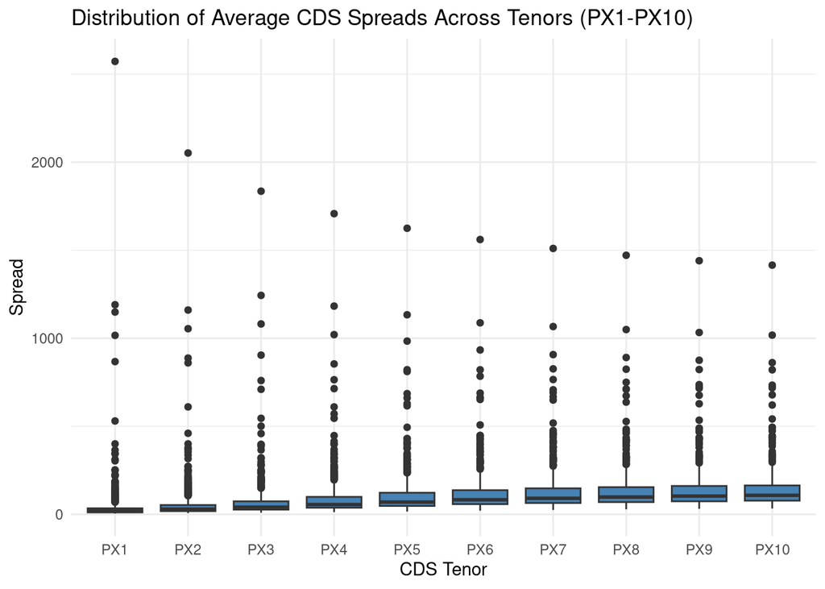

```r
library(reshape2)
library(ggplot2)

cds_long <- melt(cds_avg[, -1], id.vars = "Company")

ggplot(cds_long, aes(x = variable, y = value)) +
  geom_boxplot(fill = "steelblue") +
  labs(title = "Distribution of Average CDS Spreads Across Tenors (PX1-PX10)",
     x = "CDS Tenor", y = "Spread") +
    theme_minimal()
```

The boxplot shows that CDS spreads generally increase with maturity, which is consistent with typical term structure behavior: longer-term contracts carry more uncertainty and higher risk premiums. The distributions are fairly stable and there are no missing values, confirming the data is well-prepared for PCA and clustering.

## 3. Principal Component Analysis (PCA)

To reduce the dimensionality of the ten CDS spread variables (PX1–PX10), we applied Principal Component Analysis (PCA) after standardizing the data. PCA helps identify the dominant components driving variance in the dataset, allowing us to summarize the spread structure and visualize companies in a low-dimensional space.

#### 3.1. Scree Plot and Cumulative Variance

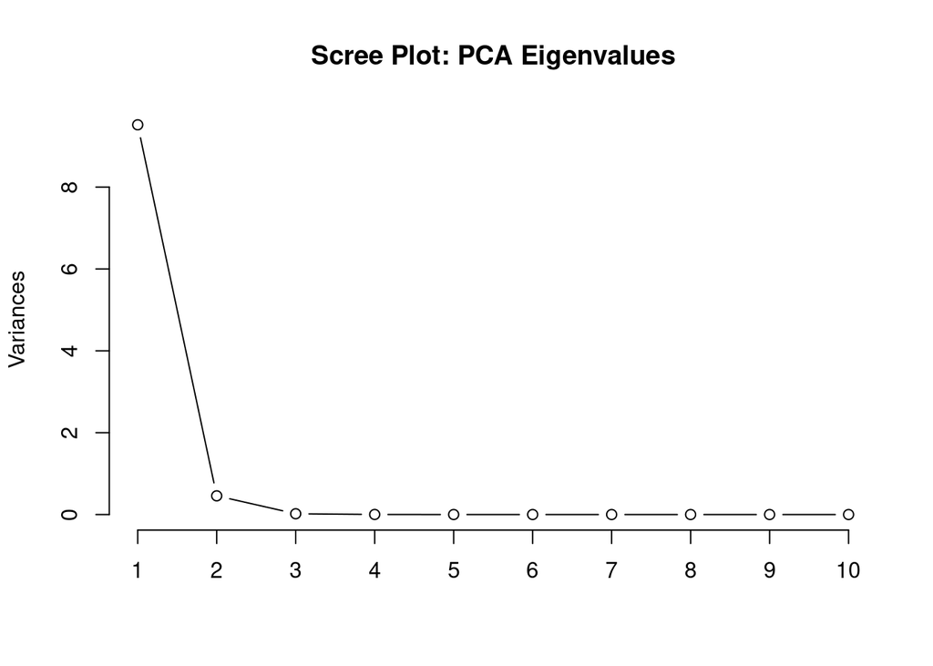

```r
cds_matrix <- cds_avg[, 3:12]  # PX1 to PX10

# Standardize
cds_scaled <- scale(cds_matrix)

# PCA
pca_result <- prcomp(cds_scaled, center = TRUE, scale. = TRUE)

# Scree plot (eigenvalues)
plot(pca_result, type = "lines", main = "Scree Plot: PCA Eigenvalues")
```

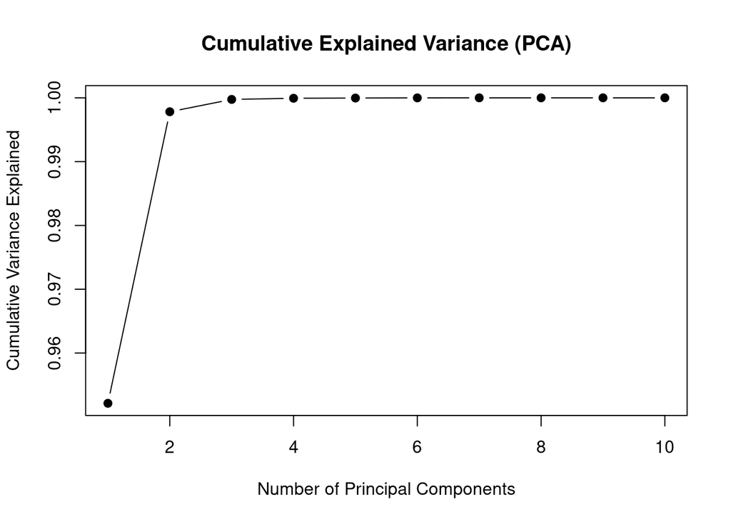

```r
# Cumulative variance
cum_var <- cumsum(pca_result$sdev^2 / sum(pca_result$sdev^2))
plot(cum_var, type = "b", pch = 19,
     xlab = "Number of Principal Components",
     ylab = "Cumulative Variance Explained",
     main = "Cumulative Explained Variance (PCA)")
```

#### 3.2. PCA Projection of Companies

```r
pca_df <- cds_avg[, c("Ticker", "Company")]
pca_df$PC1 <- pca_result$x[,1]
pca_df$PC2 <- pca_result$x[,2]
head(pca_df)
```

```
## # A tibble: 6 × 4
##   Ticker Company                      PC1     PC2
##   <chr>  <chr>                      <dbl>   <dbl>
## 1 A      Agilent Technologies Inc -0.0115  0.296
## 2 AALLN  Anglo American PLC        2.81    1.02
## 3 AAPL   Apple Inc                -1.73   -0.349
## 4 ABBNVX ABB Ltd                  -2.02   -0.603
## 5 ABBV   AbbVie Inc               -1.02   -0.256
## 6 ABC    AmerisourceBergen Corp   -0.946  -0.0509
```

The scree plot shows a strong drop after the first component, and the cumulative variance plot confirms that the first principal component alone explains 95.2% of the variance, while the first two together explain 99.8%. This means that most of the variation in CDS spreads across maturities can be captured in just two dimensions.

## 4. Clustering

With the PCA-reduced data, we apply K-means clustering to group companies based on their CDS spread profiles. Since the first two principal components explain almost all the variation in the data, we perform clustering in this two-dimensional space. This allows us to identify distinct credit risk patterns among firms.

#### 4.1. K-Means Clustering

We begin by selecting the number of clusters using the elbow method, then fit the K-means model and visualize the clusters.

##### 4.1.1. Determine number of clusters (k) using the Elbow Method

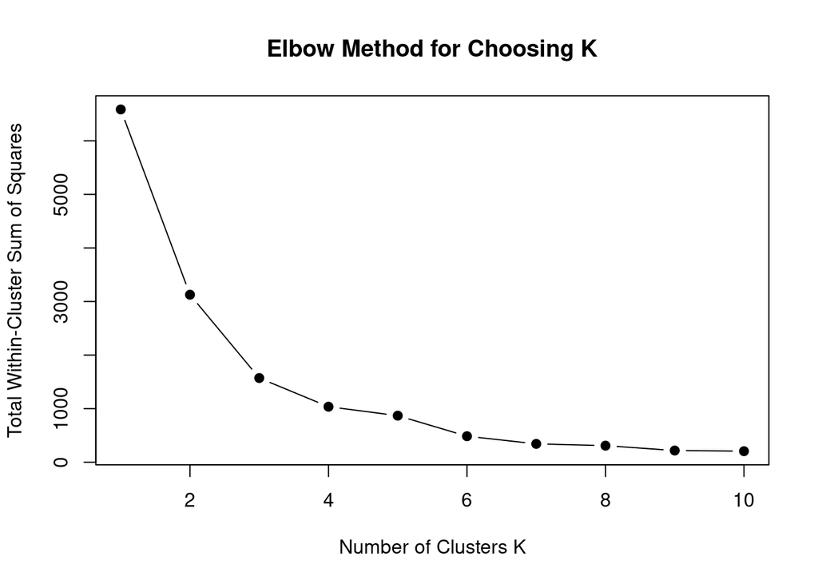

```r
# Code for computing and plotting elbow method (WSS)

set.seed(123)  # for reproducibility

wss <- sapply(1:10, function(k){
  kmeans(pca_df[, c("PC1", "PC2")], centers = k, nstart = 10)$tot.withinss
})

plot(1:10, wss, type = "b", pch = 19,
     xlab = "Number of Clusters K",
     ylab = "Total Within-Cluster Sum of Squares",
     main = "Elbow Method for Choosing K")
```

##### 4.1.2. Perform K-means with chosen k (let’s try k = 3 as a start)

```r
# Code to fit K-means with k = 3 and assign clusters
kmeans_result <- kmeans(pca_df[, c("PC1", "PC2")], centers = 3, nstart = 25)
pca_df$Cluster <- as.factor(kmeans_result$cluster)
```